# Analyse des facteurs de risque de décès en soins intensifs

Hamza QURESHI

2026-01-06

## 1. Introduction

Dans ce projet, nous nous intéressons à l’analyse des facteurs de risque de décès des patients admis en soins intensifs. L’objectif est de déterminer quelles variables influencent le risque de décès à partir des données collectées dans l’unité de soins intensifs. Nous allons utiliser une régression logistique binaire pour modéliser ce risque.

## 2. Préparation des données

Les variables qualitatives, telles que le sexe, la chirurgie, et l’infection, doivent être transformées en facteurs, sinon elles sont inutilisables. De plus, les valeurs manquantes ou aberrantes doivent être gérées avant de procéder à l’analyse, on a donc supprimé les valeurs manquantes et corrigé la valeur aberrante de “10”.

## 3. Statistiques descriptives

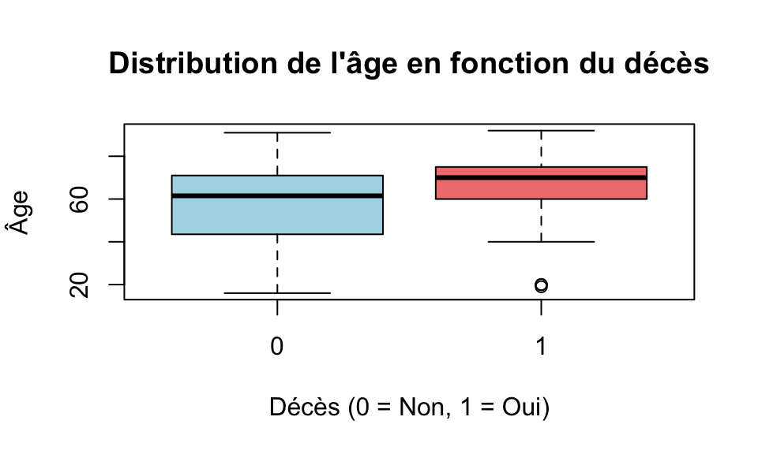

| **Characteristic** | **0** N = 188<sup>1</sup> | **1** N = 68<sup>1</sup> | **p-value**<sup>2</sup> |
| --- | --- | --- | --- |
| AGE | 62 (44, 71) | 70 (60, 75) | <0.001 |
| SEXE |  |  | 0.8 |
| 0 | 120 (64%) | 42 (62%) |  |
| 1 | 68 (36%) | 26 (38%) |  |
| CHIR_MED |  |  | <0.001 |
| 0 | 77 (41%) | 44 (65%) |  |
| 1 | 111 (59%) | 24 (35%) |  |
| INF_J0 |  |  | 0.017 |
| 0 | 117 (62%) | 31 (46%) |  |
| 1 | 71 (38%) | 37 (54%) |  |
| TA_SYS | 132 (112, 153) | 126 (90, 140) | 0.002 |
| FC | 92 (80, 116) | 96 (81, 121) | 0.4 |
| URG_NURG |  |  | <0.001 |
| 0 | 59 (31%) | 4 (5.9%) |  |
| 1 | 129 (69%) | 64 (94%) |  |
| PO2 | 85 (73, 96) | 84 (71, 99) | >0.9 |
| PH | 7.36 (7.31, 7.42) | 7.34 (7.30, 7.40) | 0.14 |
| BICAR | 26.0 (21.6, 30.8) | 24.2 (21.2, 30.3) | 0.2 |
| CONSC |  |  | <0.001 |
| 0 | 184 (98%) | 44 (65%) |  |
| 1 | 0 (0%) | 8 (12%) |  |
| 2 | 4 (2.1%) | 16 (24%) |  |
| GLASGOW | 14 (12, 15) | 13 (6, 14) | 0.001 |

<sup>1</sup> Median (Q1, Q3); n (%)  
<sup>2</sup> Wilcoxon rank sum test; Pearson’s Chi-squared test; Fisher’s exact test

Le statut de décès semble être lié à l’âge, avec les patients décédés étant plus âgés en moyenne que les survivants. Cependant, la disparité d’âge dans les survivants est plus large que chez les décédés, ce qui pourrait indiquer que les survivants ont une plus grande variation d’âge.

Ensuite nous voyons que l’âge, la chirurgie, l’infection à l’admission, la pression artérielle systolique, l’état de conscience et le score de Glasgow sont des facteurs significativement associés au risque de décès en soins intensifs comme le montrent leurs p-values très basses. Les variables telles que le pH, PO2 et les bicarbonates n’ont pas d’impact significatif sur ce risque comme l’indiquent leurs p-values élevées.

## 4. Modélisation logistique

Nous appliquons une régression logistique pour identifier les variables explicatives qui influencent le risque de décès (variable dépendante DECEDE).

```
##
## Call:
## glm(formula = DECEDE ~ AGE + SEXE + CHIR_MED + INF_J0 + TA_SYS +
##     FC + PO2 + PH + BICAR + CONSC + GLASGOW, family = binomial,
##     data = icu)
##
## Coefficients:
##               Estimate Std. Error z value Pr(>|z|)
## (Intercept)  1.989e+01  1.584e+01   1.255 0.209375
## AGE          3.653e-02  1.096e-02   3.332 0.000861 ***
## SEXE1       -1.719e-01  3.696e-01  -0.465 0.641857
## CHIR_MED1   -1.026e+00  3.982e-01  -2.577 0.009961 **
## INF_J01     -5.100e-02  3.799e-01  -0.134 0.893198
## TA_SYS      -1.574e-02  5.817e-03  -2.705 0.006823 **
## FC          -6.747e-04  7.089e-03  -0.095 0.924184
## PO2          1.271e-02  9.563e-03   1.329 0.183853
## PH          -3.394e+00  2.153e+00  -1.576 0.114991
## BICAR       -5.864e-03  2.890e-02  -0.203 0.839184
## CONSC1       2.134e+01  1.234e+03   0.017 0.986203
## CONSC2       4.880e+00  1.547e+00   3.154 0.001610 **
## GLASGOW      2.276e-01  1.330e-01   1.711 0.087044 .
## ---
## Signif. codes:  0 '***' 0.001 '**' 0.01 '*' 0.05 '.' 0.1 ' ' 1
##
## (Dispersion parameter for binomial family taken to be 1)
##
##     Null deviance: 296.38  on 255  degrees of freedom
## Residual deviance: 206.44  on 243  degrees of freedom
## AIC: 232.44
##
## Number of Fisher Scoring iterations: 16
```

Le modèle logistique binaire a été appliqué avec la variable DECEDE comme variable dépendante et plusieurs variables explicatives. Voici les principales étapes de l’analyse :

Coefficients et p-values : Les p-values sont cruciales pour déterminer quelles variables sont significativement associées au risque de décès. En général : Si p-value < 0,05, cela signifie que la variable a un effet significatif sur le risque de décès. Si p-value ≥ 0,05, cela signifie que la variable n’a pas d’effet significatif sur le risque de décès.

Donc voici l’interprétation des coefficients :

AGE : Un coefficient positif et une p-value faible suggèrent que l’âge a un effet significatif sur le risque de décès (en général, plus on est âgé, plus le risque de décès est élevé).

SEXE : Si la p-value est non significative, cela signifie que le sexe n’a pas d’impact important sur la mortalité, à condition que d’autres variables soient prises en compte.

CHIR_MED : Un coefficient négatif pour chirurgie pourrait signifier qu’une chirurgie diminue le risque de décès (cela pourrait être le cas si la chirurgie améliore la survie).

Autres variables : Variables comme TA_SYS (pression artérielle systolique), CONSC (état de conscience), GLASGOW (score de Glasgow) pourraient aussi affecter le risque de décès, mais leurs effets dépendent des p-values et des odds ratios associés.

# Selection des variables

Après avoir créé le modèle complet, nous allons utiliser la méthode stepwise pour effectuer une sélection de variables basée sur le critère AIC. Cette méthode permettra de réduire le modèle aux variables les plus pertinentes.

# Quantification des effets

Ensuite, nous allons quantifier l’impact de chaque variable explicative sur le risque de décès en utilisant les Odds Ratios (OR). Les OR permettent d’interpréter l’effet de chaque facteur sur le risque de décès.

| **Characteristic** | **OR** | **95% CI** | **p-value** |
| --- | --- | --- | --- |
| AGE | 1.04 | 1.02, 1.06 | 0.001 |
| CHIR_MED |  |  |  |
| 0 | — | — |  |
| 1 | 0.37 | 0.18, 0.74 | 0.006 |
| TA_SYS | 0.98 | 0.97, 1.00 | 0.007 |
| PH | 0.05 | 0.00, 2.87 | 0.2 |
| CONSC |  |  |  |
| 0 | — | — |  |
| 1 | 1,434,609,580 | 0.00, | >0.9 |
| 2 | 96.5 | 5.78, 2,190 | 0.002 |
| GLASGOW | 1.23 | 0.96, 1.61 | 0.11 |

Abbreviations: CI = Confidence Interval, OR = Odds Ratio

AGE (OR = 1.04) : Chaque année supplémentaire augmente légèrement les odds de décès de 4 %.

CHIR_MED (OR = 0.37) : Les patients ayant subi une chirurgie ont un risque de décès réduit de 63 % par rapport à ceux qui n’ont pas subi de chirurgie.

TA_SYS (OR = 0.98) : La pression artérielle systolique a un effet modéré avec un OR proche de 1, ce qui suggère que la pression artérielle joue un rôle protecteur, mais cet effet n’est pas très marqué.

CONSC (OR = 1,434,609,580) : L’état de conscience est fortement associé au risque de décès, mais l’OR très élevé peut être lié à une quasi-séparation des données (quand toutes les valeurs sont identiques ou presque, ce qui empêche d’obtenir des résultats fiables).

Les intervals de confiance à 95 % (IC95%) aident à évaluer la précision de l’OR. Si l’intervalle contient 1, cela suggère que l’effet n’est pas statistiquement significatif.

# Prédictions

```
##      ID proba_deces
## 1     1  0.04463309
## 2     2  0.34292557
## 3     3  0.16161564
## 4     4  0.14443585
## 253 253  0.03926574
## 254 254  0.29758838
## 255 255  0.99999996
## 256 256  0.94905612
```

Les patients ayant une probabilité élevée de décès (proche de 1) sont plus susceptibles de décéder, et ceux ayant une probabilité faible (proche de 0) sont plus susceptibles de survivre. Ces valeurs peuvent être utilisées pour classer les patients en fonction du seuil que tu choisis (par exemple, un seuil de 0,5, où une probabilité supérieure à 0,5 signifie “décédé” et une probabilité inférieure signifie “survivant”). Le modèle discrimine assez bien entre les décédés et les survivants.

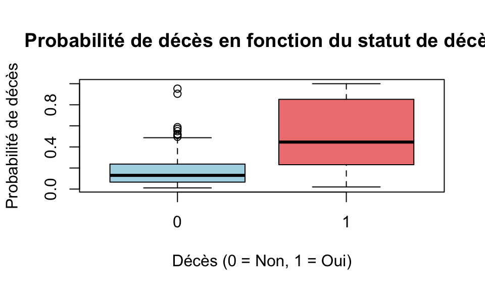

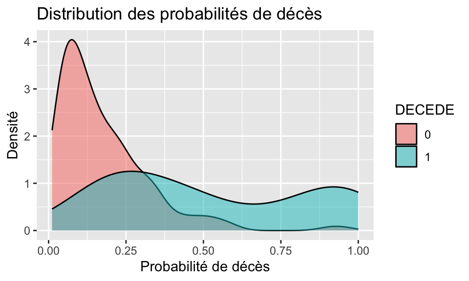

# Adéquation du modèle

L’objectif de cette partie est de vérifier la qualité du modèle logistique et de calculer la performance du modèle à l’aide de la courbe ROC et de l’aire sous la courbe (AUC).

```
## [1] 0
```

Nous allons maintenant classifier les patients en décédés ou survivants en utilisant un seuil de 0,5. Tous les patients ayant une probabilité supérieure à 0,5 seront considérés comme décédés, et les autres comme survivants.

```
##
##     décédé survivant
##   0      7       181
##   1     29        39
```

```
##
##         décédé  survivant
##   0 0.03723404 0.96276596
##   1 0.42647059 0.57352941
```

Nous allons calculer la courbe ROC et l’Aire Sous la Courbe (AUC) pour évaluer la capacité du modèle à discriminer entre les patients décédés et survivants.

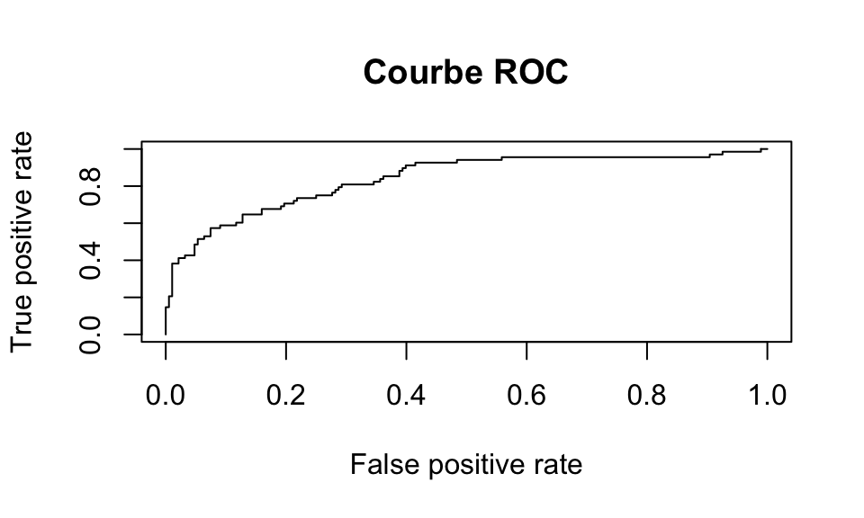

```
## [1] 0.8406602
```

Une AUC de 0,84 (comme dans tes résultats) montre que le modèle est assez performant pour distinguer les patients décédés des survivants. La courbe ROC doit être tracée pour voir si elle se trouve bien au-dessus de la diagonale, ce qui signifie que le modèle est meilleur qu’un modèle aléatoire.

Nous allons maintenant examiner les résidus du modèle pour vérifier la qualité de l’ajustement. Les résidus doivent être indépendants et normalement distribués pour que le modèle soit valide.

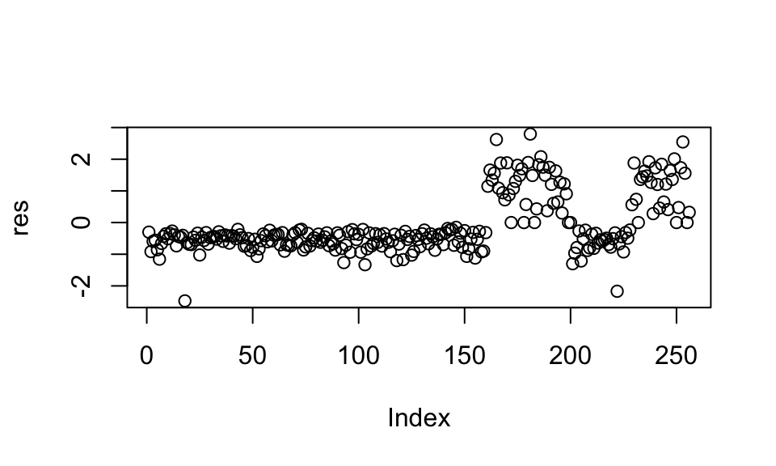

Les résidus doivent être aléatoirement distribués autour de zéro, sans forme particulière. Si certains résidus ont des valeurs élevées (|résidu| > 2), ces observations sont difficiles à prédire et peuvent être considérées comme atypiques. Les résidus négatifs ou positifs élevés peuvent signaler des erreurs de prédiction où le modèle sous-estime ou surestime le risque de décès. Les observations atypiques doivent être examinées de plus près, mais leur exclusion dépend du contexte clinique.

```
##      ID DECEDE proba_deces
## 18   18      0  0.95300886
## 165 165      1  0.03223176
## 181 181      1  0.02017950
## 186 186      1  0.11552479
## 222 222      0  0.90482313
## 249 249      1  0.13277015
## 253 253      1  0.03926574
```